# My First R Markdown File

Ryan Wesslen

September 28, 2017

## Loading Data

Let’s get started. First, we can write text to describe what we’re doing next.

For example, let’s load `tidyverse`.

```r
library(tidyverse)
```

Next, let’s use the `read_csv()` function load our dataset.

```r
tweets <- read_csv("../data/CharlotteTweets20Sample.csv")
```

Recall – what’s going on with the path?

Why have we not needed to set our working directory?

### View Data

```r
head(tweets$body, n = 3)
```

```
## [1] "Treon to WR is a really good move by Mac, very familiar with playbook. Very good runner in open space too"
## [2] "primus #vsco #vscocam #primus #primussucks #charlotte #bojanglescoliseum #livemusic… https://t.co/IqI6BIPVqn"
## [3] "WOAH!!!!!!"
```

## Getting a time series of the Tweets

Next, let’s convert the date to allow us to plot our data.

```r
# converts YYYY-MM-DD HH:MM:SS to string of YYYY-MM-DD
tweets$day <- as.Date(tweets$postedTime)

# recall from dplyr
dayCount <- tweets %>%
  group_by(day) %>%
  summarise(Count=n())
```

Next, we’re going to use `ggplot2` to plot our time series. We’ll formally introduce ggplot more next week.

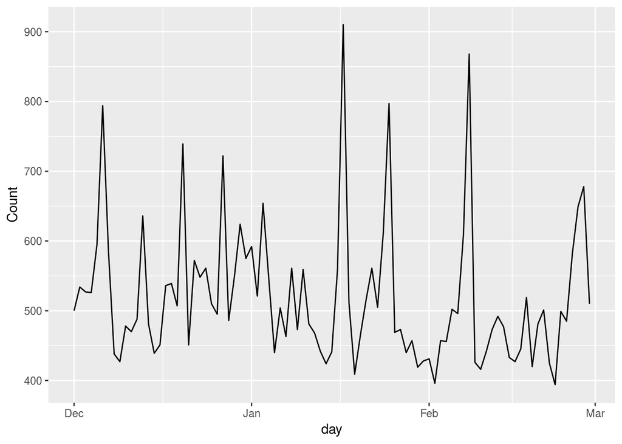

```r
ggplot(dayCount, aes(x = day, y = Count)) +
      geom_line()
```

Not bad. We can add a few parameters to this plot to make it pretty.

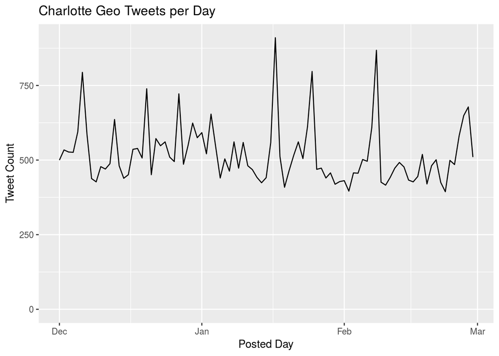

```r
ggplot(dayCount, aes(x = day, y = Count)) +
      geom_line() +
      labs(x = "Posted Day", y = "Tweet Count", title = "Charlotte Geo Tweets per Day") +
      expand_limits(y = 0) # set y axis to start at zero
```

What the heck are those spikes?

## Hashtag & Mentions

One way we can check is to look at the most prominent hashtags and mentions.

To do this, we can run a pre-specified function ([regular expression](https://www.rstudio.com/wp-content/uploads/2016/09/RegExCheatsheet.pdf)) that will keep only hashtags or handles from the body of our tweet.

```r
getCommonHashtags <- function(text, n=20){
  hashtags <- regmatches(text, gregexpr("#(\\d|\\w)+",text))
  hashtags <- unlist(hashtags)
  tab <- table(hashtags)
  return(head(sort(tab, dec=TRUE), n=n))
}

getCommonHandles <- function(text, n=20){
  handles <- regmatches(text, gregexpr('@([0-9_A-Za-z]+)',text, perl=TRUE))
  handles <- unlist(handles)
  tab <- table(handles)
  return(head(sort(tab, dec=TRUE), n=n))
}
```

For example, now we can run:

```r
getCommonHashtags(tweets$body)
```

```
## hashtags
## #KeepPounding    #Charlotte           #NC   #realestate    #charlotte
##           487           458           443           429           256
## #keeppounding      #traffic       #trndnl        #photo      #listing
##           234           212           205           185           159
##          #clt       #Repost      #realtor         #CIAA         #SB50
##           154           144           133           123           109
##     #Panthers     #CIAA2016      #Concord          #CLT     #panthers
##            95            89            88            86            86
```

or …

```r
getCommonHandles(tweets$body)
```

```
## handles
##      @cltairport        @Panthers        @midnight        @panthers
##              218              212              180              130
##      @EthanDolan            @ness         @hornets    @GraysonDolan
##              117               80               78               77
##    @SportsCenter       @F3theFort @realDonaldTrump     @nodabrewing
##               69               64               64               63
##    @CampersHaven   @marcuslemonis       @F3Isotope      @marielawtf
##               58               52               48               43
##          @oakley @LifeTimeFitness  @ChickenNGreens            @wcnc
##               39               38               36               36
```

Ah… maybe they’re Carolina Panther related!

## Searching for Panther Tweets

Let’s use a different regular expression and save only the tweets that include three keywords…

```r
panthers <- c("#keeppounding", "#panthers", "@panthers")

# find only the Tweets that contain words in the first list
hit <- grepl(paste(panthers, collapse = "|"), tolower(tweets$body))

# create a column to separate panther tweets and non-Panther tweets
tweets$pantherFlag <- ifelse(hit, "Panther Tweet", "Non-Panther Tweet")
```

With our new flag, let’s rerun our time series but differentiate between Panther and non-Panther tweets.

```r
dayCount <- tweets %>%
  group_by(day, pantherFlag) %>%
  summarise(Count=n())
```

Next, we’re going to use `ggplot2` to plot our time series. We’ll formally introduce ggplot more next week.

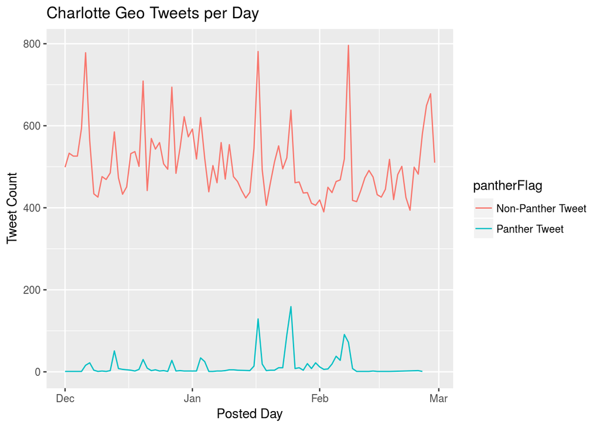

```r
ggplot(dayCount, aes(x = day, y = Count, color = pantherFlag)) +
      geom_line() +
      labs(x = "Posted Day", y = "Tweet Count", title = "Charlotte Geo Tweets per Day") +
      expand_limits(y = 0) # set y axis to start at zero
```

This is a good start, but it still looks like we may have missed some Tweets.

Querying Twitter data is an incredibly hard problem (much harder than many researchers realize!).

For example, [King, Lam and Roberts (2017)](https://gking.harvard.edu/publications/computer-assisted-keyword-and-document-set-discovery-fromunstructured-text) investigates this problem and finds that the choice of keywords can drastically affect results.

For a deeper analysis, see my [Fall 2016 Twitter Workshop Day 1](https://cdn.rawgit.com/wesslen/fall-2016-pm-twitter-text/44b3a896/Day1/exercise1.html) Exercise.